# 8.9 Time Series - Beer Production

The Beer production dataset provides a time series data for monthly beer production in Australia, for the period Jan 1956 – Aug 1995. Objective:

- Check for the stationarity of your data using Rolling Statistics and Dickey-Fuller test.
- If stationarity is present, remove it using differencing in Python.

```python
import numpy as np
import pandas as pd
from datetime import datetime as dt
from statsmodels.tsa.stattools import adfuller, acf, pacf
from statsmodels.tsa.arima_model import ARIMA
import math
import matplotlib.pyplot as plt
%matplotlib inline
from matplotlib.pylab import rcParams
rcParams['figure.figsize'] = 15,6

# import warning to disable python warning
import warnings
warnings.filterwarnings('ignore')
```

```python
# load and read the dataset
data = pd.read_csv('monthly-beer-production-in-austr.csv')
data.head()
```

|  | Month | Monthly beer production in Australia |
| --- | --- | --- |
| 0 | 1956-01 | 93.2 |
| 1 | 1956-02 | 96.0 |
| 2 | 1956-03 | 95.2 |
| 3 | 1956-04 | 77.1 |
| 4 | 1956-05 | 70.9 |

Using the lambda function to filter months and add day value as 15

Set the index to months

```python
data['Month'] = data['Month'].apply(lambda x: dt(int(x[:4]), int(x[5:]), 15))
data = data.set_index('Month')
data.head()
```

| Month | Monthly beer production in Australia |
| --- | --- |
| 1956-01-15 | 93.2 |
| 1956-02-15 | 96.0 |
| 1956-03-15 | 95.2 |
| 1956-04-15 | 77.1 |
| 1956-05-15 | 70.9 |

```python
# Assigning the beer production data time series variable
ts = data['Monthly beer production in Australia']
```

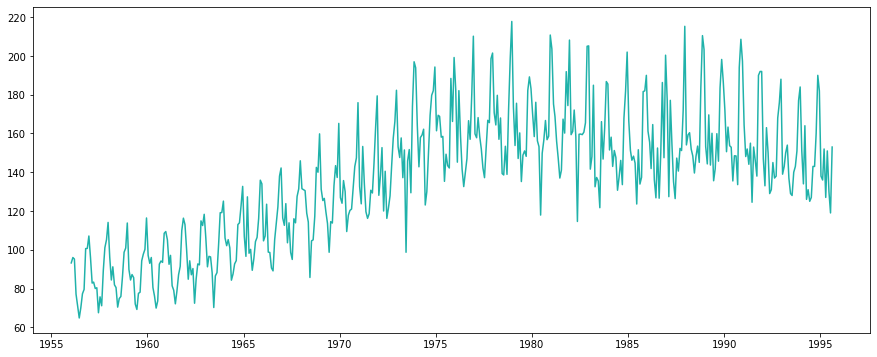

```python
# Plotting the time series
plt.plot(ts, color='lightseagreen')
```

```python
# Transform the series using log decomposition
ts_log = np.log(ts)
```

Stationarity Check We will write a function fro performing rolling statistics and dickey fuller test.

```python
def test_stationarity(timeseries):
    rolmean = timeseries.rolling(window=52, center=False).mean()
    rolstd = timeseries.rolling(window=52, center=False).std()

    # plotting rolling statistics
    orig = plt.plot(timeseries, color='blue', label='Original')
    mean = plt.plot(rolmean, color='red', label='Rolling Mean')
    std = plt.plot(rolstd, color='black', label='Rolling Std')
    plt.legend(loc='best')
    plt.title('Rolling Mean & Standard Deviation')
    plt.show(block=False)

    # let's perform the dickey fuller test
    print('Results of Dickey-Fuller Test')
    dftest = adfuller(timeseries, autolag='AIC')  # initialize
    dfoutput = pd.Series(dftest[0:4], index=['Test Statistic', 'p-value', '#Lags Used', 'Number of Observations Used'])
    # initializing the critical value variable
    for key, value in dftest[4].items():
        dfoutput['Critical Value (%s)'%key] = value
    print(dfoutput)
```

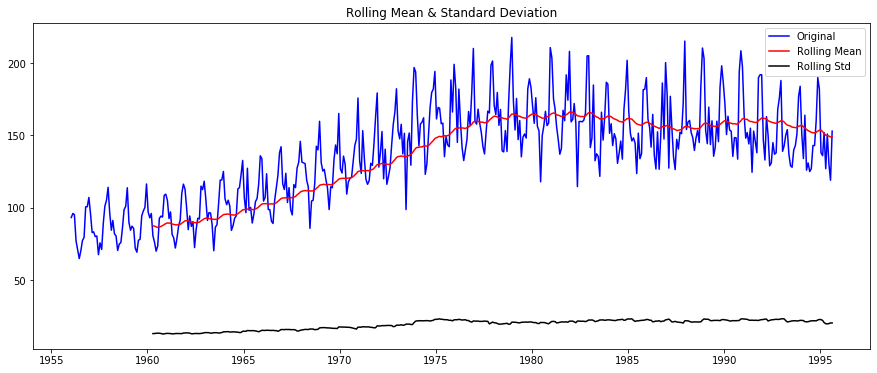

```
Results of Dickey-Fuller Test
Test Statistic                  -2.282661
p-value                          0.177621
#Lags Used                      17.000000
Number of Observations Used    458.000000
Critical Value (1%)             -3.444709
Critical Value (5%)             -2.867871
Critical Value (10%)            -2.570142
dtype: float64
```

```python
# Now let's apply the data to the function and see the stationarity
test_stationarity(data['Monthly beer production in Australia'])
```

The test statistics is greater than the critical value so it shows that the time series is not stationary so we will fail to reject the null hypothesis.

### Decomposing the data

Let's also plot the moving average

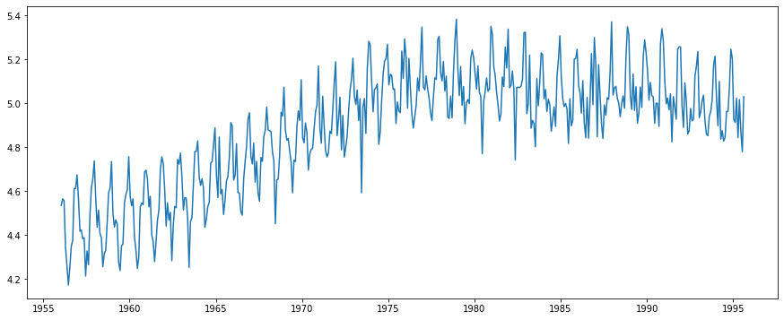

```python
plt.plot(ts_log)
```

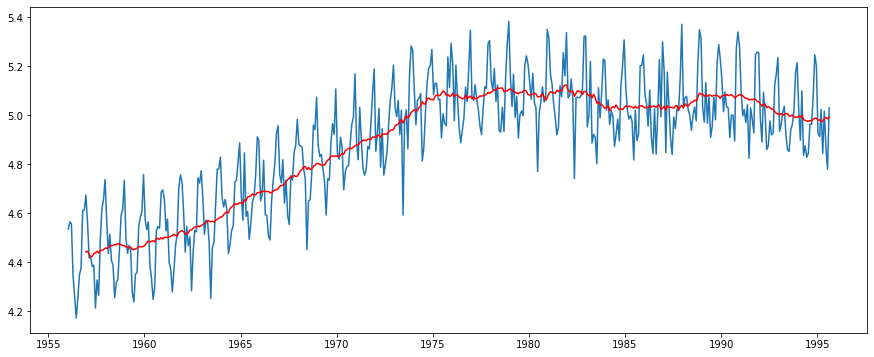

```python
# initialize the moving average variable
movingAverage = ts_log.rolling(window=12).mean()
movingSTD = ts_log.rolling(window=12).std()
plt.plot(ts_log)
plt.plot(movingAverage, color='red')
```

```python
ts_log_mv_diff = ts_log - movingAverage
ts_log_mv_diff.head(12)

# drop the null values from the time series data
ts_log_mv_diff.dropna(inplace=True)
ts_log_mv_diff.head(10)
```

```
Month
1956-12-15    0.231830
1957-01-15    0.118994
1957-02-15   -0.015558
1957-03-15    0.001590
1957-04-15   -0.041908
1957-05-15   -0.047399
1957-06-15   -0.225688
1957-07-15   -0.117442
1957-08-15   -0.173166
1957-09-15    0.045062
Name: Monthly beer production in Australia, dtype: float64
```

Let's put the time series data into the function and check for stationarity

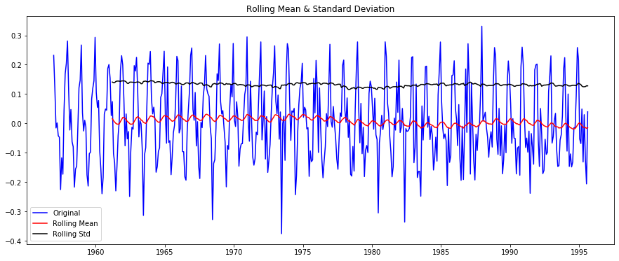

```
Results of Dickey-Fuller Test
Test Statistic                  -3.432559
p-value                          0.009898
#Lags Used                      13.000000
Number of Observations Used    451.000000
Critical Value (1%)             -3.444933
Critical Value (5%)             -2.867970
Critical Value (10%)            -2.570195
dtype: float64
```

```python
test_stationarity(ts_log_mv_diff)
```

The result of the Dickey Fuller Test shows that the Test statistics is less than the 5% of Critical Value.

That tells us that we are 95% confident that this series is stationary. We can REJECT the null hypothesis.